# Lab 5

```
Saraliba Auch
11/4/2026
```

## Proposal

**My Question:**

What is the signifcance of the drop in luminosity caused by [HIP-65 A b](https://en.wikipedia.org/wiki/HIP_65Ab) transiting its host star. What is the sigma of this event?

HIP-65 A b is a Hot Jupiter that orbits every 0.98 days. Its transit lasts for roughly 0.79 hours. Data if from the [NASA Exoplanet Archeive](https://exoplanetarchive.ipac.caltech.edu/overview/HIP%2065%20A%20b#planet_HIP-65-A-b_collapsible).

**What data I will be using:**

**How I will use the data to answer my question:**

There are 6 different light curves from the TESS mission. Using the lightcurves, I will develop the a distribution of the star's flux without the influence of the planetary transit. Since I know the orbital period of the planet, I will be able to fold the data. I will have to normailze the lightcurves in order to properly find the average flux. Since I will be looking at a star, I would predict it's light follows a Gaussian distribution.

Then I would just have to find how much the planet effects the stars luminosity, and use the distribution to find the sigma of the event.

**Data Download and Initial Plot:**

Going through lightkurve tutorial:

```python
! python -m pip install lightkurve --upgrade
```

```
  Using cached lightkurve-2.6.0-py3-none-any.whl.metadata (6.5 kB)
  Using cached fbpca-1.0-py3-none-any.whl
  Using cached memoization-0.4.0-py3-none-any.whl
Using cached lightkurve-2.6.0-py3-none-any.whl (261 kB)
   ━━━━━━━━━━━━━━━━━━━━━━━━━━━━━━━━━━━━━━━━ 3/3 [lightkurve]3 [lightkurve]
```

```python
%matplotlib inline
import lightkurve as lk
import matplotlib.pyplot as plt
import numpy as np
from lightkurve import search_targetpixelfile

from astropy import units as u
from astropy import constants as const
from astropy.units import imperial
from astropy.table import vstack, QTable

import warnings
warnings.simplefilter('ignore')
```

```python
search = lk.search_lightcurve('HIP-65 A b', author = 'TESS-SPOC')
search
```

SearchResult containing 6 data products.

| # | mission | year | author | exptime s | target_name | distance arcsec |
| --- | --- | --- | --- | --- | --- | --- |
| 0 | TESS Sector 01 | 2018 | [TESS-SPOC](https://archive.stsci.edu/hlsp/tess-spoc) | 1800 | 201248411 | 0.0 |
| 1 | TESS Sector 02 | 2018 | [TESS-SPOC](https://archive.stsci.edu/hlsp/tess-spoc) | 1800 | 201248411 | 0.0 |
| 2 | TESS Sector 28 | 2020 | [TESS-SPOC](https://archive.stsci.edu/hlsp/tess-spoc) | 600 | 201248411 | 0.0 |
| 3 | TESS Sector 29 | 2020 | [TESS-SPOC](https://archive.stsci.edu/hlsp/tess-spoc) | 600 | 201248411 | 0.0 |
| 4 | TESS Sector 68 | 2023 | [TESS-SPOC](https://archive.stsci.edu/hlsp/tess-spoc) | 200 | 201248411 | 0.0 |
| 5 | TESS Sector 69 | 2023 | [TESS-SPOC](https://archive.stsci.edu/hlsp/tess-spoc) | 200 | 201248411 | 0.0 |

```python
lc_collection = search[:6].download_all()
lc_collection
```

```
LightCurveCollection of 6 objects:
    0: <TessLightCurve LABEL="TIC 201248411" SECTOR=1 AUTHOR=TESS-SPOC FLUX_ORIGIN=pdcsap_flux>
    1: <TessLightCurve LABEL="TIC 201248411" SECTOR=2 AUTHOR=TESS-SPOC FLUX_ORIGIN=pdcsap_flux>
    2: <TessLightCurve LABEL="TIC 201248411" SECTOR=28 AUTHOR=TESS-SPOC FLUX_ORIGIN=pdcsap_flux>
    3: <TessLightCurve LABEL="TIC 201248411" SECTOR=29 AUTHOR=TESS-SPOC FLUX_ORIGIN=pdcsap_flux>
    4: <TessLightCurve LABEL="TIC 201248411" SECTOR=68 AUTHOR=TESS-SPOC FLUX_ORIGIN=pdcsap_flux>
    5: <TessLightCurve LABEL="TIC 201248411" SECTOR=69 AUTHOR=TESS-SPOC FLUX_ORIGIN=pdcsap_flux>
```

```
Below are 6 subplots of the light curve data. They are divided up into 3 sections based on the time they were taken. Looking the the x-axis, you can see there is an 680.37 day difference between the first and second sets of data. There is a 1040.18 day difference between the second and third sets of data. Dividing them up this ways makes it easy to see the characteristics of the light curve.
Each color represents a different sector. Each sector denotes a specific patch of sky that TESS observed over roughly 27 days (2 orbits aroung the Earth)
```

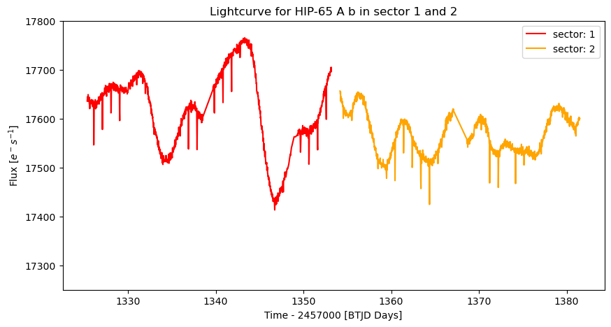

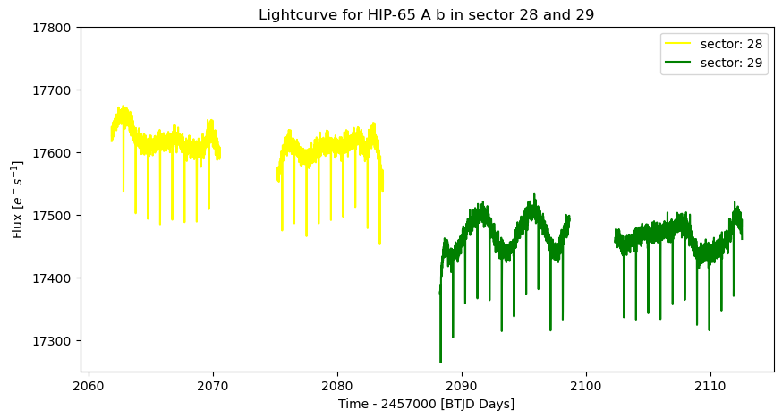

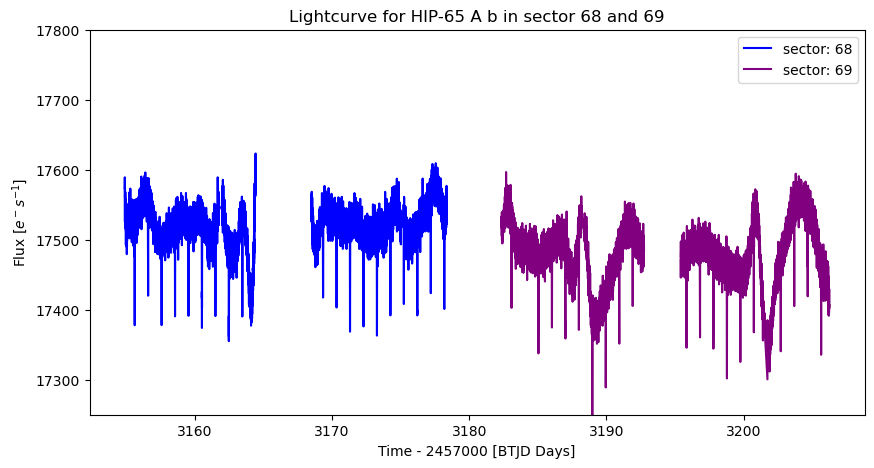

```python
fig, ax = plt.subplots(figsize = (10,5))
ax.plot(lc_collection[0]['time'].value, lc_collection[0]['flux'].value,
        label = f'sector: {lc_collection_norm[0].sector}',
       color = 'red')
ax.plot(lc_collection[1]['time'].value, lc_collection[1]['flux'].value,
        label = f'sector: {lc_collection_norm[1].sector}',
       color = 'orange')
ax.set_ylabel(r'Flux $[e^- s^{-1}]$')
ax.set_xlabel('Time - 2457000 [BTJD Days]')
ax.set_title('Lightcurve for HIP-65 A b in sector 1 and 2')
ax.set_ylim(17250,17800)
ax.legend()

fig, ax = plt.subplots(figsize = (10,5))
ax.plot(lc_collection[2]['time'].value, lc_collection[2]['flux'].value,
        label = f'sector: {lc_collection_norm[2].sector}',
       color = 'yellow')
ax.plot(lc_collection[3]['time'].value, lc_collection[3]['flux'].value,
        label = f'sector: {lc_collection_norm[3].sector}',
       color = 'green')
ax.set_ylabel(r'Flux $[e^- s^{-1}]$')
ax.set_xlabel('Time - 2457000 [BTJD Days]')
ax.set_title('Lightcurve for HIP-65 A b in sector 28 and 29')
ax.set_ylim(17250,17800)
ax.legend()

fig, ax = plt.subplots(figsize = (10,5))
ax.plot(lc_collection[4]['time'].value, lc_collection[4]['flux'].value,
        label = f'sector: {lc_collection_norm[4].sector}',
       color = 'blue')
ax.plot(lc_collection[5]['time'].value, lc_collection[5]['flux'].value,
        label = f'sector: {lc_collection_norm[5].sector}',
       color = 'purple')
ax.set_ylabel(r'Flux $[e^- s^{-1}]$')
ax.set_xlabel('Time - 2457000 [BTJD Days]')
ax.set_title('Lightcurve for HIP-65 A b in sector 68 and 69')
ax.set_ylim(17250,17800)
ax.legend()
```

```
The plots show that as the exposure time decrease, the noisier the data becomes. Looking at the table above, we can see sector 1 and 2 have an exposure time of 1800 sections, 28 and 29 are 600 seconds, and sector 68 and 69 are 200 seconds.
```

## Normalizing the Data

```
First I will normalize the data. The data is normalized by dividing the flux and flux error by the median flux
```

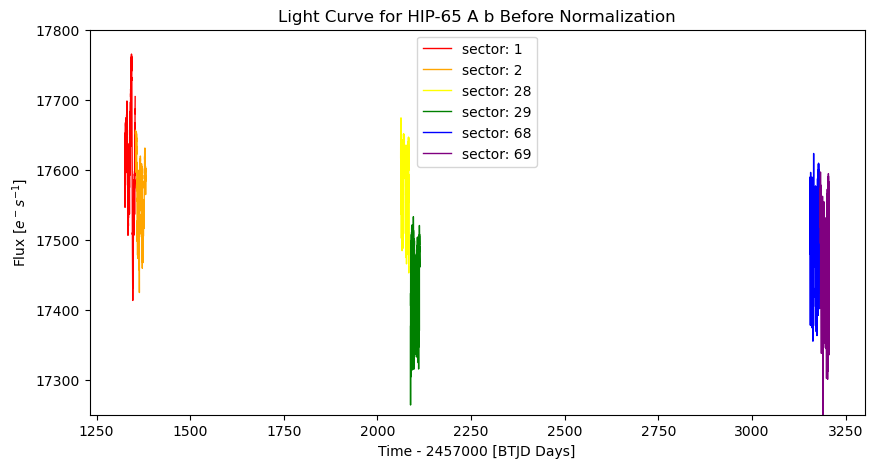

```python
# This is what all of the light curves look before they are normalized.
# The graph shows the light curves misaligned from each other, and this is likely do to varing background noises
# Normalizing the data will fix correct this

fig, ax = plt.subplots(figsize = (10,5))
ax.plot(lc_collection[0]['time'].value, lc_collection[0]['flux'].value,
        label = f'sector: {lc_collection_norm[0].sector}',
       color = 'red',
       linewidth = 1)
ax.plot(lc_collection[1]['time'].value, lc_collection[1]['flux'].value,
        label = f'sector: {lc_collection_norm[1].sector}',
       color = 'orange',
       linewidth = 1)
ax.plot(lc_collection[2]['time'].value, lc_collection[2]['flux'].value,
        label = f'sector: {lc_collection_norm[2].sector}',
       color = 'yellow',
       linewidth = 1)
ax.plot(lc_collection[3]['time'].value, lc_collection[3]['flux'].value,
        label = f'sector: {lc_collection_norm[3].sector}',
       color = 'green',
       linewidth = 1)
ax.plot(lc_collection[4]['time'].value, lc_collection[4]['flux'].value,
        label = f'sector: {lc_collection_norm[4].sector}',
       color = 'blue',
       linewidth = 1)
ax.plot(lc_collection[5]['time'].value, lc_collection[5]['flux'].value,
        label = f'sector: {lc_collection_norm[5].sector}',
       color = 'purple',
       linewidth = 1)
ax.set_ylabel(r'Flux $[e^- s^{-1}]$')
ax.set_xlabel('Time - 2457000 [BTJD Days]')
ax.set_title('Light Curve for HIP-65 A b Before Normalization')
ax.set_ylim(17250,17800)
ax.legend()
```

```python
# Normalizes each light curve used in the data set
lc_collection_norm = []
for lc in lc_collection:
    lc_collection_norm.append(lc.normalize())
```

```python
# The data is in a QTable
# This gives me an overview of the information contained in the table.

lc_collection_norm[0].info()
```

```
<TessLightCurve length=1166>
      name       dtype      unit      format      class      n_bad
--------------- ------- ------------ -------- -------------- -----
           time  object                                 Time     0
           flux float32              {:14.7e} MaskedQuantity     0
       flux_err float32              {:14.7e} MaskedQuantity     0
       timecorr float32            d {:14.7e}       Quantity     0
      cadenceno   int32                {:10d}         Column     0
   centroid_col float64          pix {:10.5f} MaskedQuantity     0
   centroid_row float64          pix {:10.5f} MaskedQuantity     0
       sap_flux float32 electron / s {:14.7e} MaskedQuantity     0
   sap_flux_err float32 electron / s {:14.7e} MaskedQuantity     0
        sap_bkg float32 electron / s {:14.7e} MaskedQuantity     0
    sap_bkg_err float32 electron / s {:14.7e} MaskedQuantity     0
    pdcsap_flux float32 electron / s {:14.7e} MaskedQuantity     0
pdcsap_flux_err float32 electron / s {:14.7e} MaskedQuantity     0
        quality   int32                {:16b}         Column     0
     psf_centr1 float64          pix {:10.5f} MaskedQuantity  1166
 psf_centr1_err float32          pix {:14.7e} MaskedQuantity  1166
     psf_centr2 float64          pix {:10.5f} MaskedQuantity  1166
 psf_centr2_err float32          pix {:14.7e} MaskedQuantity  1166
     mom_centr1 float64          pix {:10.5f} MaskedQuantity     0
 mom_centr1_err float32          pix {:14.7e} MaskedQuantity     0
     mom_centr2 float64          pix {:10.5f} MaskedQuantity     0
 mom_centr2_err float32          pix {:14.7e} MaskedQuantity     0
      pos_corr1 float32          pix {:14.7e} MaskedQuantity     0
      pos_corr2 float32          pix {:14.7e} MaskedQuantity     0
```

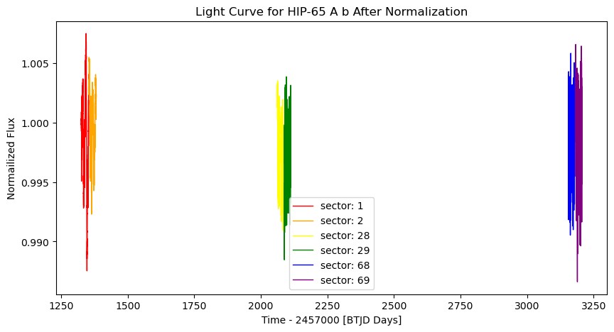

```python
fig, ax = plt.subplots(figsize = (10,5))
ax.plot(lc_collection_norm[0]['time'].value, lc_collection_norm[0]['flux'].value,
        label = f'sector: {lc_collection_norm[0].sector}',
       color = 'red',
       linewidth = 1)
ax.plot(lc_collection_norm[1]['time'].value, lc_collection_norm[1]['flux'].value,
        label = f'sector: {lc_collection_norm[1].sector}',
       color = 'orange',
       linewidth = 1)
ax.plot(lc_collection_norm[2]['time'].value, lc_collection_norm[2]['flux'].value,
        label = f'sector: {lc_collection_norm[2].sector}',
       color = 'yellow',
       linewidth = 1)
ax.plot(lc_collection_norm[3]['time'].value, lc_collection_norm[3]['flux'].value,
        label = f'sector: {lc_collection_norm[3].sector}',
       color = 'green',
       linewidth = 1)
ax.plot(lc_collection_norm[4]['time'].value, lc_collection_norm[4]['flux'].value,
        label = f'sector: {lc_collection_norm[4].sector}',
       color = 'blue',
       linewidth = 1)
ax.plot(lc_collection_norm[5]['time'].value, lc_collection_norm[5]['flux'].value,
        label = f'sector: {lc_collection_norm[5].sector}',
       color = 'purple',
       linewidth = 1)
ax.set_ylabel('Normailized Flux')
ax.set_xlabel('Time - 2457000 [BTJD Days]')
ax.set_title('Light Curve for HIP-65 A b After Normalization')
ax.legend()
```

```
The normalized data looks much better, but it is difficult to see that actual light curve properties when they are all on one graph. The three sectors are graphed below.
```

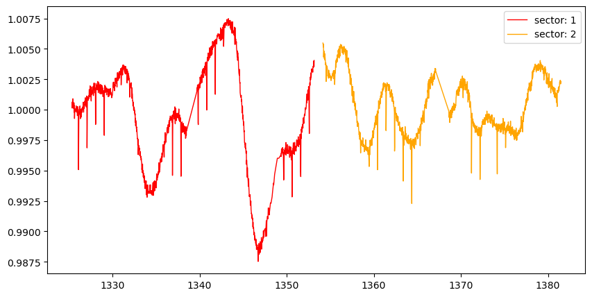

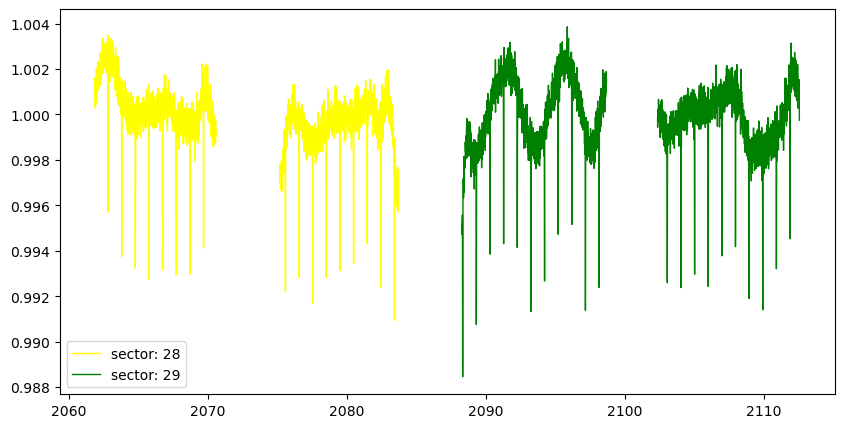

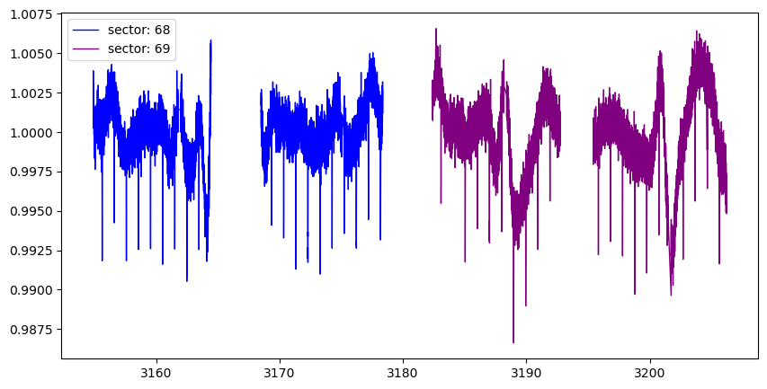

```python
fig, ax = plt.subplots(figsize = (10,5))
ax.plot(lc_collection_norm[0]['time'].value, lc_collection_norm[0]['flux'].value,
        label = f'sector: {lc_collection_norm[0].sector}',
       color = 'red',
       linewidth = 1)
ax.plot(lc_collection_norm[1]['time'].value, lc_collection_norm[1]['flux'].value,
        label = f'sector: {lc_collection_norm[1].sector}',
       color = 'orange',
       linewidth = 1)
ax.legend()

fig, ax = plt.subplots(figsize = (10,5))
ax.plot(lc_collection_norm[2]['time'].value, lc_collection_norm[2]['flux'].value,
        label = f'sector: {lc_collection_norm[2].sector}',
       color = 'yellow',
       linewidth = 1)
ax.plot(lc_collection_norm[3]['time'].value, lc_collection_norm[3]['flux'].value,
        label = f'sector: {lc_collection_norm[3].sector}',
       color = 'green',
       linewidth = 1)
ax.legend()

fig, ax = plt.subplots(figsize = (10,5))
ax.plot(lc_collection_norm[4]['time'].value, lc_collection_norm[4]['flux'].value,
        label = f'sector: {lc_collection_norm[4].sector}',
       color = 'blue',
       linewidth = 1)
ax.plot(lc_collection_norm[5]['time'].value, lc_collection_norm[5]['flux'].value,
        label = f'sector: {lc_collection_norm[5].sector}',
       color = 'purple',
       linewidth = 1)
ax.legend()
```

## Folding the Data

```python
orbital_period = 0.981 # This values is from the NASA Exoplanet Archieve

sector_1 = lc_collection_norm[0]
sector_2 = lc_collection_norm[1]
sector_28 = lc_collection_norm[2]
sector_29 = lc_collection_norm[3]
sector_68 = lc_collection_norm[4]
sector_69 = lc_collection_norm[5]

#combines all of the the normalized data
HIP65 = vstack([sector_1, sector_2, sector_28, sector_29, sector_68, sector_69])
HIP65.info()
```

```
<TessLightCurve length=30148>
      name       dtype      unit      format      class      n_bad
--------------- ------- ------------ -------- -------------- -----
           time  object                                 Time     0
           flux float32              {:14.7e} MaskedQuantity  5356
       flux_err float32              {:14.7e} MaskedQuantity  5356
       timecorr float32            d {:14.7e}       Quantity     0
      cadenceno   int32                {:10d}         Column     0
   centroid_col float64          pix {:10.5f} MaskedQuantity     1
   centroid_row float64          pix {:10.5f} MaskedQuantity     1
       sap_flux float32 electron / s {:14.7e} MaskedQuantity     1
   sap_flux_err float32 electron / s {:14.7e} MaskedQuantity     1
        sap_bkg float32 electron / s {:14.7e} MaskedQuantity     1
    sap_bkg_err float32 electron / s {:14.7e} MaskedQuantity     1
    pdcsap_flux float32 electron / s {:14.7e} MaskedQuantity  5356
pdcsap_flux_err float32 electron / s {:14.7e} MaskedQuantity  5356
        quality   int32                {:16b}         Column     0
     psf_centr1 float64          pix {:10.5f} MaskedQuantity 30148
 psf_centr1_err float32          pix {:14.7e} MaskedQuantity 30148
     psf_centr2 float64          pix {:10.5f} MaskedQuantity 30148
 psf_centr2_err float32          pix {:14.7e} MaskedQuantity 30148
     mom_centr1 float64          pix {:10.5f} MaskedQuantity     1
 mom_centr1_err float32          pix {:14.7e} MaskedQuantity     1
     mom_centr2 float64          pix {:10.5f} MaskedQuantity     1
 mom_centr2_err float32          pix {:14.7e} MaskedQuantity     1
      pos_corr1 float32          pix {:14.7e} MaskedQuantity    55
      pos_corr2 float32          pix {:14.7e} MaskedQuantity    55
```

```python
fold_time1 = sector_1['time'].value % orbital_period
fold_time2 = sector_2['time'].value % orbital_period
fold_time28 = sector_28['time'].value % orbital_period
fold_time29 = sector_29['time'].value % orbital_period
fold_time68 = sector_68['time'].value % orbital_period
fold_time69 = sector_69['time'].value % orbital_period
```